# from book ‘ggplot2 essential’ movie examples simplified

Илья Кочергин

29 апреля 2016 г

```r
library(ggplot2)
library(ggplot2movies) # Набор данных movies вынесен из новых версий ggplot2
library(dplyr)
```

## Наборы данных, используемые в примерах

## Movie dataset (пакет ggplot2)

Набор данных movies переместили в отдельный пакет `ggplot2movies` из пакета `ggplot2` в последних версиях.

#### Описание из пакета `ggplot2movies`:

- title. Title of the movie.
- year. Year of release.
- budget. Total budget (if known) in US dollars
- length. Length in minutes.
- rating. Average IMDB user rating.
- votes. Number of IMDB users who rated this movie.
- r1-10. Multiplying by ten gives percentile (to nearest 10%) of users who rated this movie a 1.
- mpaa. MPAA rating.
- action, animation, comedy, drama, documentary, romance, short. Binary variables representing if movie was classified as belonging to that genre.

```r
glimpse(movies)
```

```
## Observations: 58,788
## Variables: 24
## $ title       (chr) "$", "$1000 a Touchdown", "$21 a Day Once a Month"...
## $ year        (int) 1971, 1939, 1941, 1996, 1975, 2000, 2002, 2002, 19...
## $ length      (int) 121, 71, 7, 70, 71, 91, 93, 25, 97, 61, 99, 96, 10...
## $ budget      (int) NA, NA, NA, NA, NA, NA, NA, NA, NA, NA, NA, NA, NA...
## $ rating      (dbl) 6.4, 6.0, 8.2, 8.2, 3.4, 4.3, 5.3, 6.7, 6.6, 6.0, ...
## $ votes       (int) 348, 20, 5, 6, 17, 45, 200, 24, 18, 51, 23, 53, 44...
## $ r1          (dbl) 4.5, 0.0, 0.0, 14.5, 24.5, 4.5, 4.5, 4.5, 4.5, 4.5...
## $ r2          (dbl) 4.5, 14.5, 0.0, 0.0, 4.5, 4.5, 0.0, 4.5, 4.5, 0.0,...
## $ r3          (dbl) 4.5, 4.5, 0.0, 0.0, 0.0, 4.5, 4.5, 4.5, 4.5, 4.5, ...
## $ r4          (dbl) 4.5, 24.5, 0.0, 0.0, 14.5, 14.5, 4.5, 4.5, 0.0, 4....
## $ r5          (dbl) 14.5, 14.5, 0.0, 0.0, 14.5, 14.5, 24.5, 4.5, 0.0, ...
## $ r6          (dbl) 24.5, 14.5, 24.5, 0.0, 4.5, 14.5, 24.5, 14.5, 0.0,...
## $ r7          (dbl) 24.5, 14.5, 0.0, 0.0, 0.0, 4.5, 14.5, 14.5, 34.5, ...
## $ r8          (dbl) 14.5, 4.5, 44.5, 0.0, 0.0, 4.5, 4.5, 14.5, 14.5, 4...
## $ r9          (dbl) 4.5, 4.5, 24.5, 34.5, 0.0, 14.5, 4.5, 4.5, 4.5, 4....
## $ r10         (dbl) 4.5, 14.5, 24.5, 45.5, 24.5, 14.5, 14.5, 14.5, 24....
## $ mpaa        (chr) "", "", "", "", "", "", "R", "", "", "", "", "", "...
## $ Action      (int) 0, 0, 0, 0, 0, 0, 1, 0, 0, 0, 0, 0, 0, 0, 1, 1, 0,...
## $ Animation   (int) 0, 0, 1, 0, 0, 0, 0, 0, 0, 0, 0, 0, 0, 0, 0, 0, 0,...
## $ Comedy      (int) 1, 1, 0, 1, 0, 0, 0, 0, 0, 0, 0, 0, 1, 0, 1, 1, 0,...
## $ Drama       (int) 1, 0, 0, 0, 0, 1, 1, 0, 1, 0, 1, 0, 0, 0, 0, 0, 1,...
## $ Documentary (int) 0, 0, 0, 0, 0, 0, 0, 1, 0, 0, 0, 0, 0, 0, 0, 0, 0,...
## $ Romance     (int) 0, 0, 0, 0, 0, 0, 0, 0, 0, 0, 0, 0, 0, 0, 0, 0, 0,...
## $ Short       (int) 0, 0, 1, 0, 0, 0, 0, 1, 0, 0, 0, 0, 1, 1, 0, 0, 0,...
```

```r
d1 <-data.frame(movies[movies$Action==1, c("budget", "Short",
"year")])
d1$Type <- "Animation"
d2 <-data.frame(movies[movies$Animation==1, c("budget", "Short",
"year")])
d2$Type <- "Animation"
d3 <-data.frame(movies[movies$Comedy==1, c("budget", "Short",
"year")])
d3$Type <- "Comedy"
d4 <-data.frame(movies[movies$Drama==1, c("budget", "Short",
"year")])
d4$Type <- "Drama"
d5 <-data.frame(movies[movies$Documentary==1, c("budget", "Short",
"year")])
d5$Type <- "Documentary"
d6 <-data.frame(movies[movies$Romance==1, c("budget", "Short",
"year")])
d6$Type <- "Romance"
myMovieData <- rbind(d1, d2, d3, d4, d5, d6)
names(myMovieData) <- c("Budget", "Short", "Year", "Type" )
```

Реструктуризованный набор данных (по жанрам)

```r
glimpse(myMovieData)
```

```
## Observations: 55,676
## Variables: 4
## $ Budget (int) NA, NA, NA, NA, NA, NA, NA, NA, NA, NA, NA, NA, NA, NA,...
## $ Short  (int) 0, 0, 0, 0, 0, 0, 0, 0, 0, 0, 0, 0, 0, 0, 0, 1, 0, 0, 0...
## $ Year   (int) 2002, 1983, 1987, 1988, 1974, 1975, 1981, 1990, 1970, 1...
## $ Type   (chr) "Animation", "Animation", "Animation", "Animation", "An...
```

## Bar plots

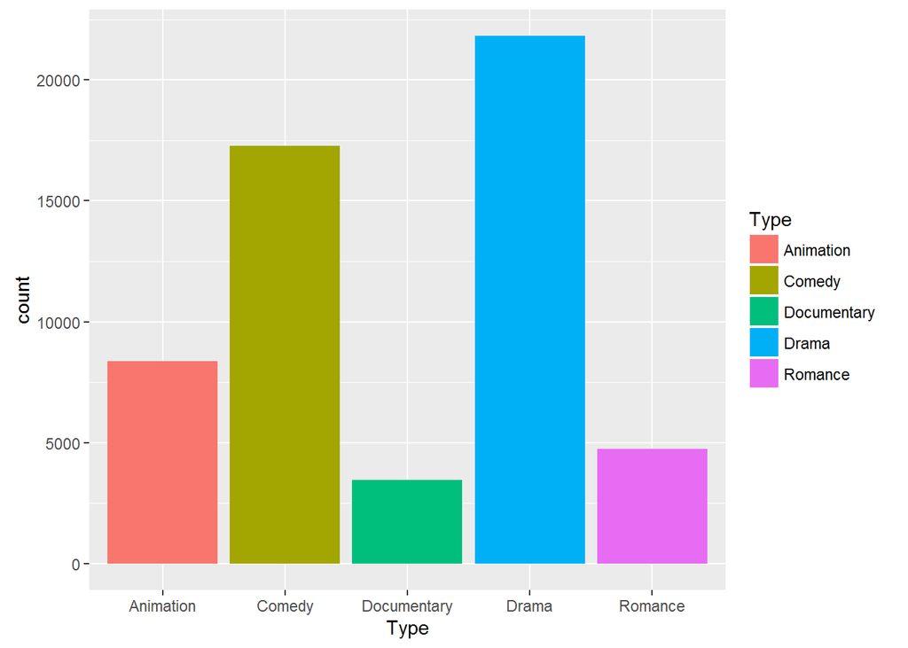

```r
ggplot(myMovieData,aes(Type,fill=Type)) + geom_bar()
```

### Порядок столбцов

Для номинальных данных прядок расположения на оси X можно задать при помощи изменения порядка уровней (levels) в столбце типа фактор.

Упорядочим уровни (factor levels) для получения нужного порядка столбцов (по убыванию количества фильмов)

```r
# myMovieData_o_by_cnt <- mutate(myMovieData,Type ,)
newLevelsMovieType <- sort(table(myMovieData$Type),decreasing = T)
newLevelsMovieType
```

```
##
##       Drama      Comedy   Animation     Romance Documentary
##       21811       17271        8378        4744        3472
```

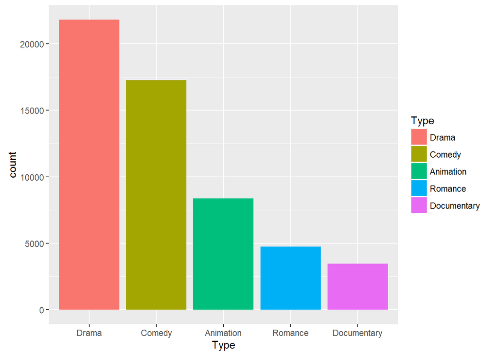

```r
myMovieData_o_by_cnt <-
  mutate(myMovieData,
        Type=factor(Type,levels = names(newLevelsMovieType)))
ggplot(myMovieData_o_by_cnt,aes(Type,fill=Type)) + geom_bar()
```

[output not shown]

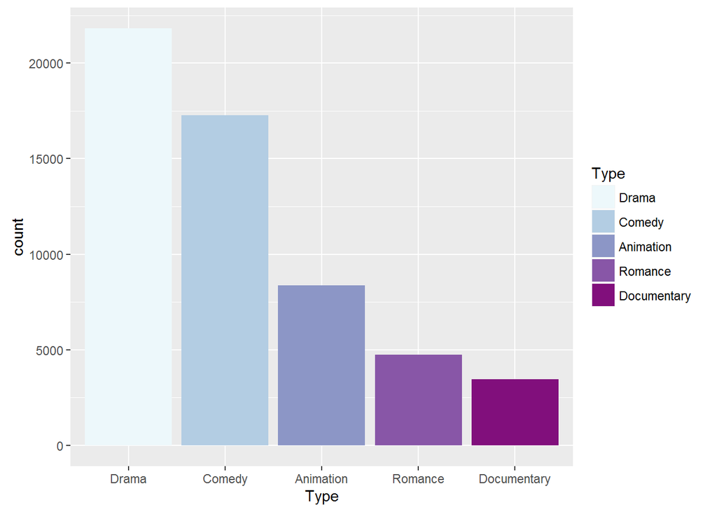

```r
bar_brewer  <-  ggplot(myMovieData_o_by_cnt,aes(Type,fill=Type)) +
  geom_bar() + scale_fill_brewer(palette="PiYG")
bar_brewer + scale_fill_brewer(palette="BuPu")
```

### Раположение прямоугольников, соответствующих одному значению X

3 варианта `position_adjustment` для `geom_bar(position="...")` :

- stack – один над другим
- dodge – один рядом с другим
- fill – заполняют всю высоту

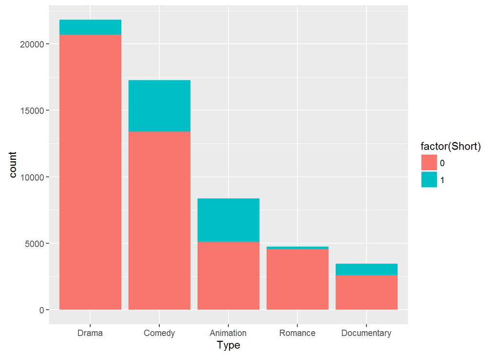

```r
gbar <-  ggplot(data=myMovieData_o_by_cnt,
                aes(x=Type, fill=factor(Short)))
gbar + geom_bar(position="stack") # default
```

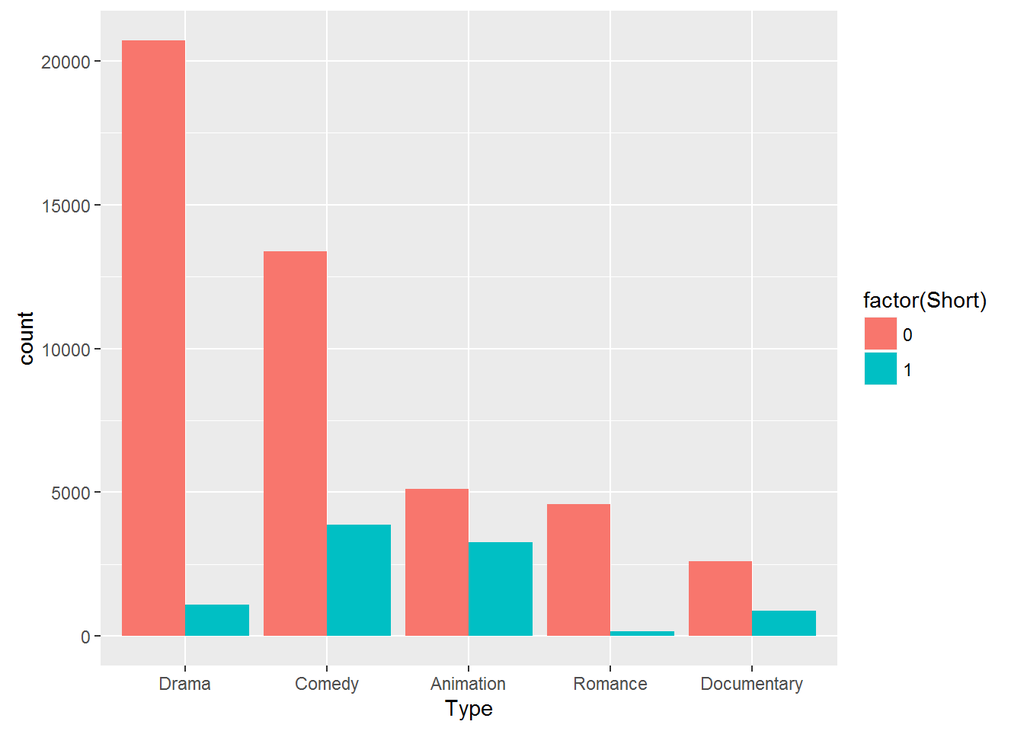

```r
gbar + geom_bar(position="dodge")
```

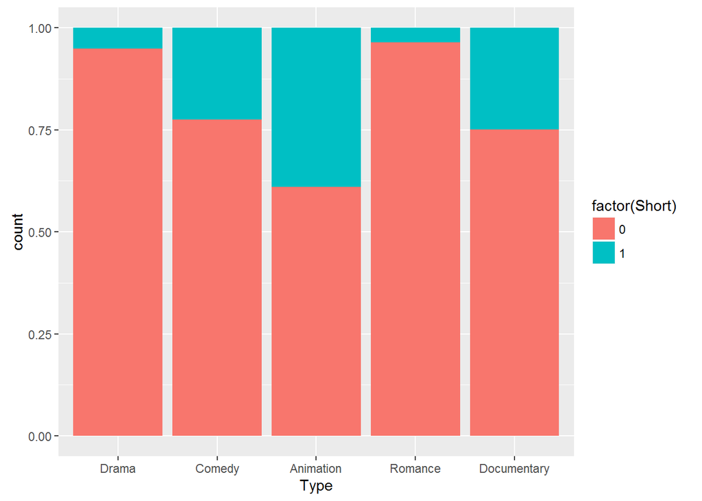

```r
gbar + geom_bar(position="fill")
```

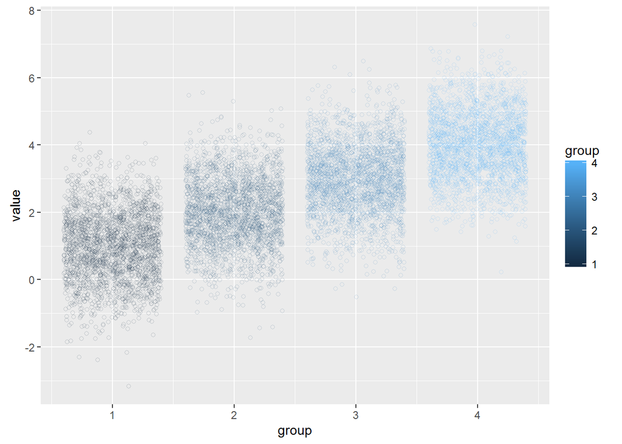

```r
dist <- data.frame(value=rnorm(10000, 1:4), group=1:4)
ggplot(dist, aes(x=group, y=value, color=group)) +
geom_jitter(alpha=0.2, shape=21)
```

[figure not shown]

```r
ggplot(dist, aes(x=group, y=value, color=factor(group))) +
geom_jitter(alpha=0.5, shape=21, width=0.5) + scale_color_brewer(palette="YlOrRd")
```

#### Пример с Boxplot

```r
gBoxPoint <-
ggplot()
```

### Шкалы и статистики

```r
myMovieData <- na.omit(myMovieData)
glimpse(myMovieData)
```

```
## Observations: 5,977
## Variables: 4
## $ Budget (int) 85000000, 76000000, 200000, 62000000, 1500, 28000000, 8...
## $ Short  (int) 0, 0, 0, 0, 0, 0, 0, 0, 0, 0, 0, 0, 0, 0, 1, 0, 0, 0, 0...
## $ Year   (int) 1999, 2003, 1916, 2001, 1996, 2001, 2000, 2004, 1958, 2...
## $ Type   (chr) "Animation", "Animation", "Animation", "Animation", "An...
```

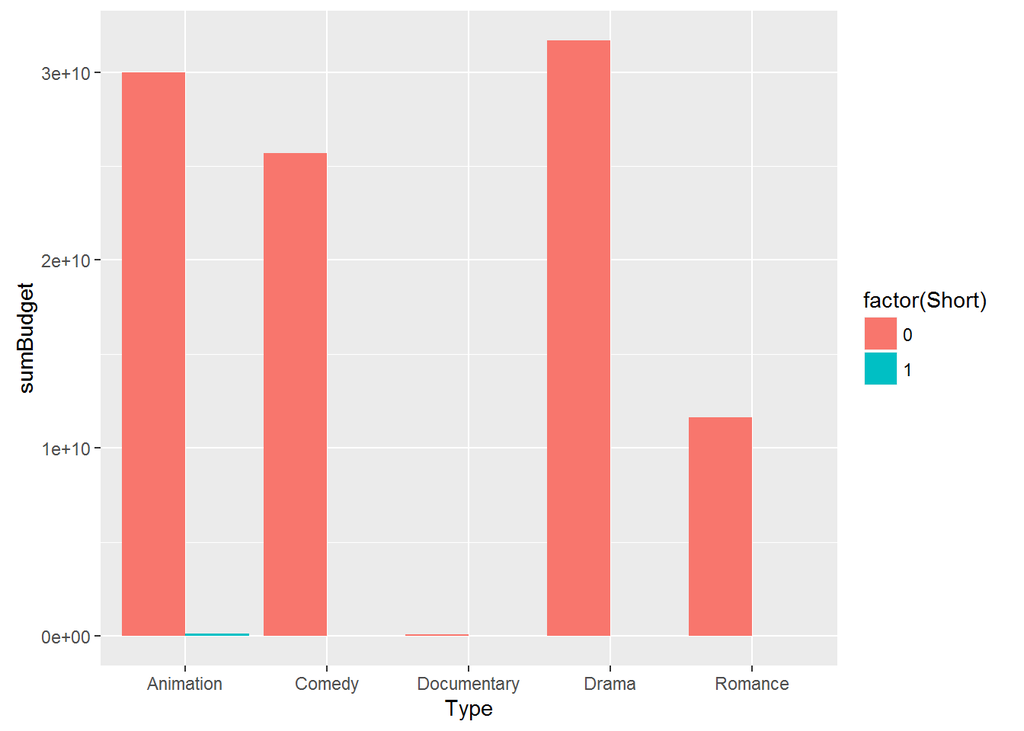

```r
myMovieByTypeByShort <-
myMovieData %>%
  group_by(Type,Short) %>%
  summarise(meanBudget=mean(Budget),sumBudget=sum(as.numeric(Budget)))

ggBudgetsByType <-
  ggplot(myMovieByTypeByShort,aes(x=Type,y=sumBudget,fill=factor(Short))) +
  geom_bar(stat="identity",position="dodge")
ggBudgetsByType
```

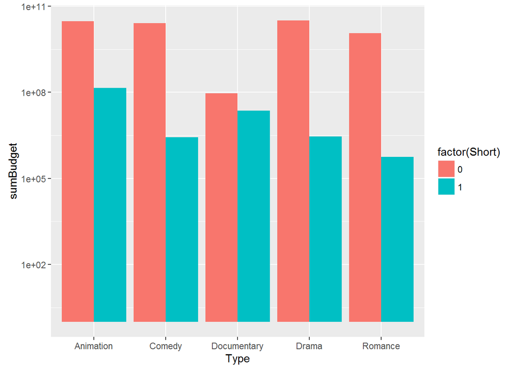

```r
ggBudgetsByType +scale_y_log10()
```

**Замечание 1** `geom_bar()` неправильно воспринимается с логарифмической шкалой по Y.

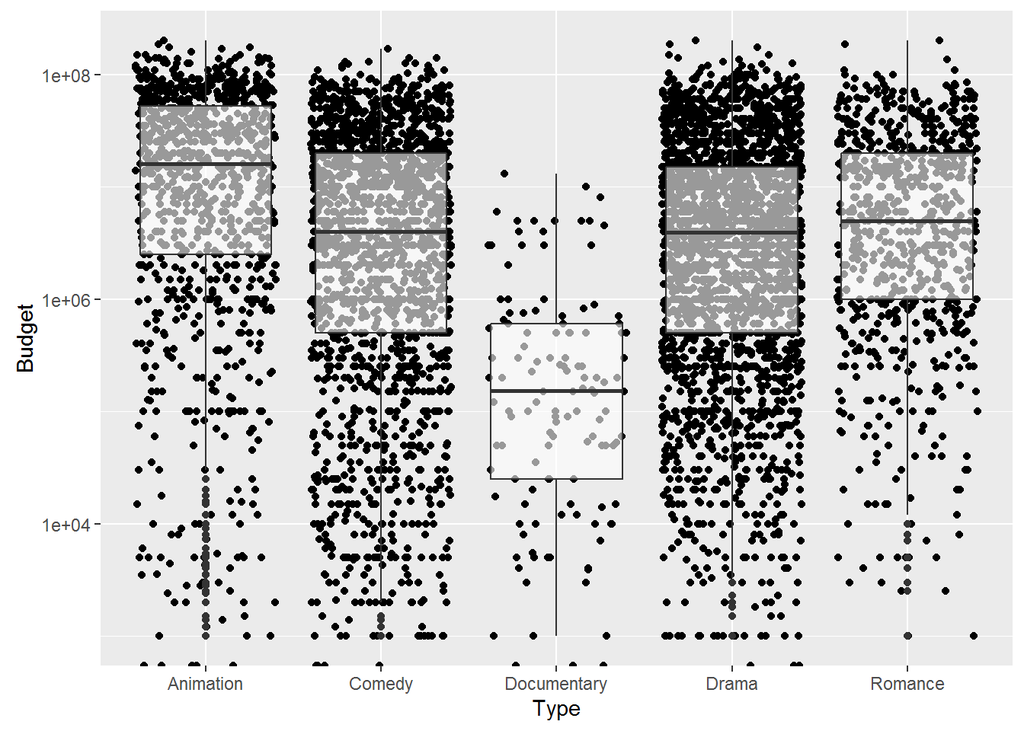

```r
ggplot(data=myMovieData,
aes(Type,Budget)) +
 geom_jitter() +
  geom_boxplot(alpha=I(0.6))+
  scale_y_log10()
```

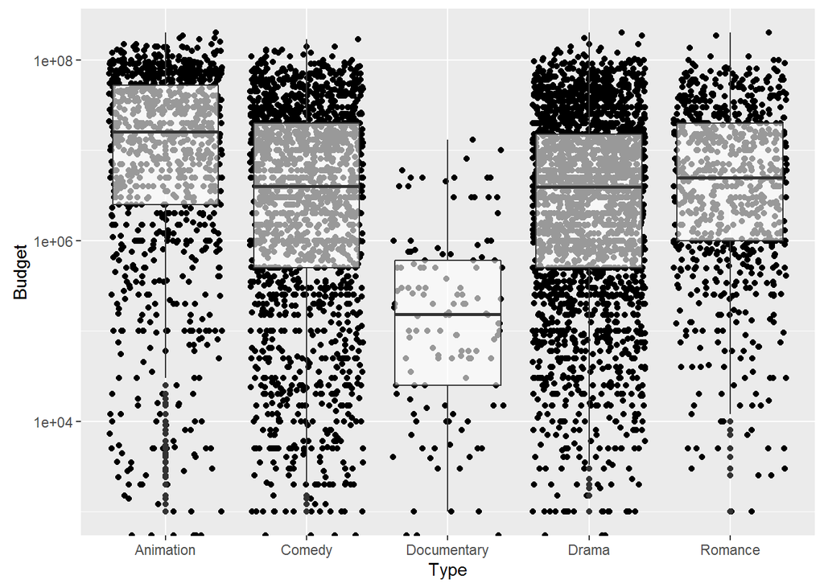

```r
ggplot(data=myMovieData,
aes(Type,Budget)) +
  geom_jitter() +
   geom_boxplot(alpha=I(0.6))+
  scale_y_log10()
```

#### Цветовые шкалы

выдержка из `help(package="RColorBrewer")`:

ColorBrewer is Copyright (c) 2002 **Cynthia Brewer**, Mark Harrower, and The Pennsylvania State University. All rights reserved. The ColorBrewer palettes have been included in this R package with permission of the copyright holder. `

There are 3 types of palettes, **sequential**, **diverging**, and **qualitative**.

1. *Sequential palettes **are suited to** ordered data **that progress from low to high.** Lightness steps **dominate the look of these schemes, with** light colors **for** low **data values to** dark colors **for** high **data** values**.
2. *Diverging palettes* put equal emphasis on mid-range critical values and extremes at both ends of the data range. The critical class or **break in the middle** of the legend is emphasized with **light colors** and **low and high extremes** are emphasized with **dark colors** that have **contrasting hues**.
3. *Qualitative palettes* do not imply magnitude differences between legend classes, and hues are used to create the primary visual differences between classes. Qualitative schemes are best suited to representing nominal or categorical data.

```r
 library(RColorBrewer)
 display.brewer.all(type = "seq")   ## количественные переменные -- правый край шкалы тёмный
```

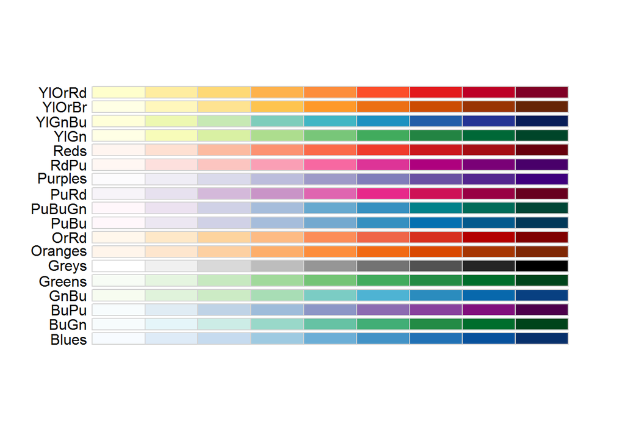

```r
 display.brewer.all(type = "div")   ## количественные переменные -- края шкалы темные
```

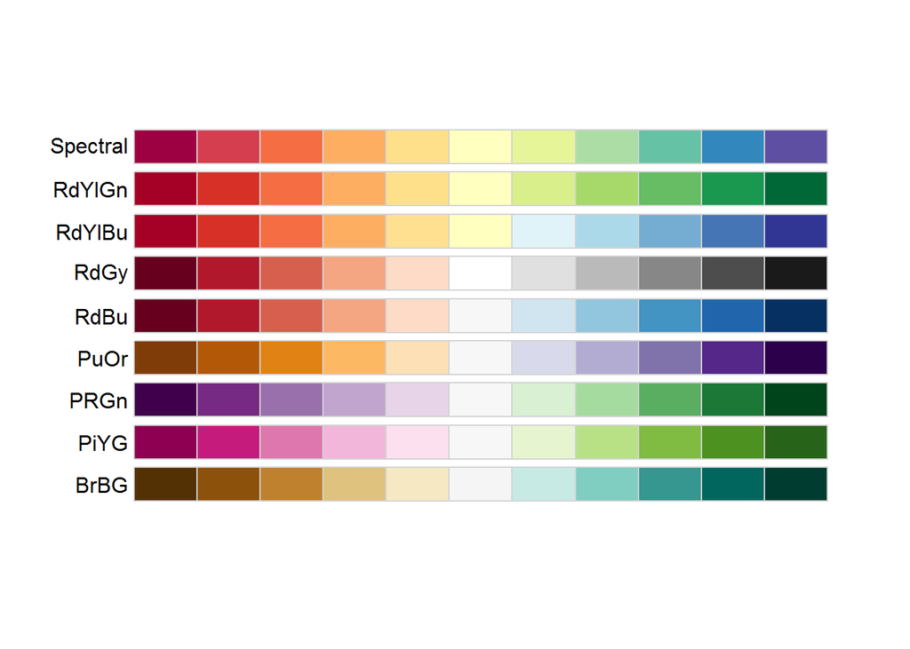

```r
 display.brewer.all(type = "qual")  ## качественные переменные -- контрастные цвета
```

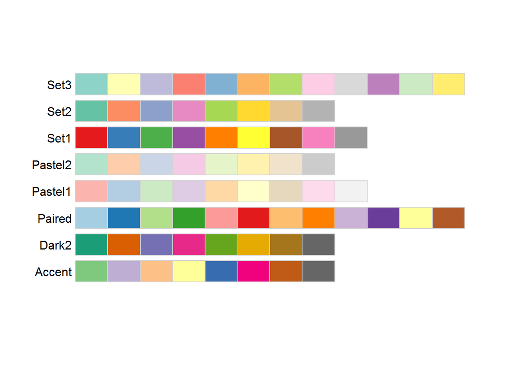

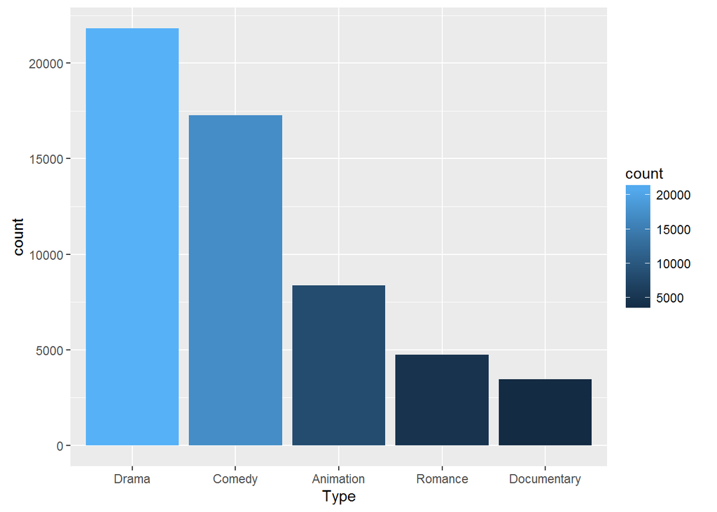

```r
gbar_cnt  <-
  ggplot(myMovieData_o_by_cnt,aes(Type,fill=..count..)) +
     geom_bar()
gbar_cnt
```

#### Параметр *alpha* – Непрозрачность

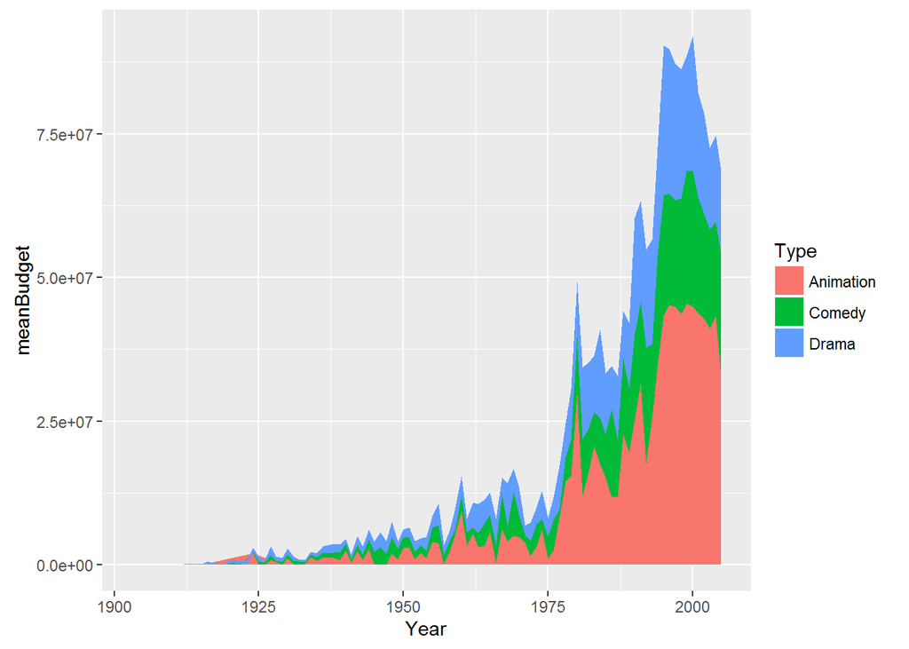

```r
movieByYearByType <- myMovieData %>%  group_by(Year,Type) %>%
  summarise(meanBudget=mean(as.numeric(Budget))) %>%
  arrange(Type,Year)
ggarea1 <- filter(movieByYearByType,Type %in% c('Drama','Comedy','Animation')) %>%
  ggplot(data=., aes(x=Year,y=meanBudget,fill=Type)) + geom_area()
ggarea1
```

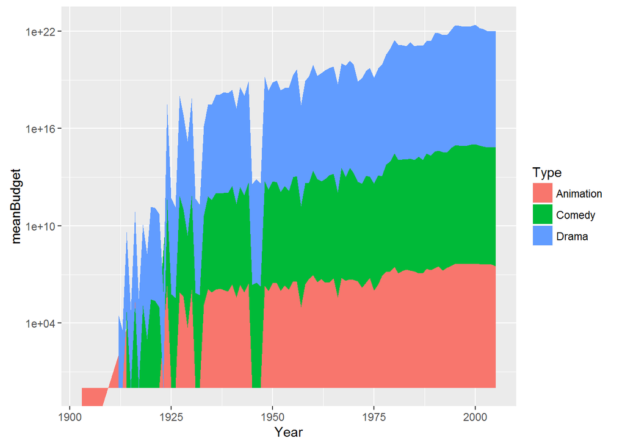

```r
ggarea1+ scale_y_log10()
```

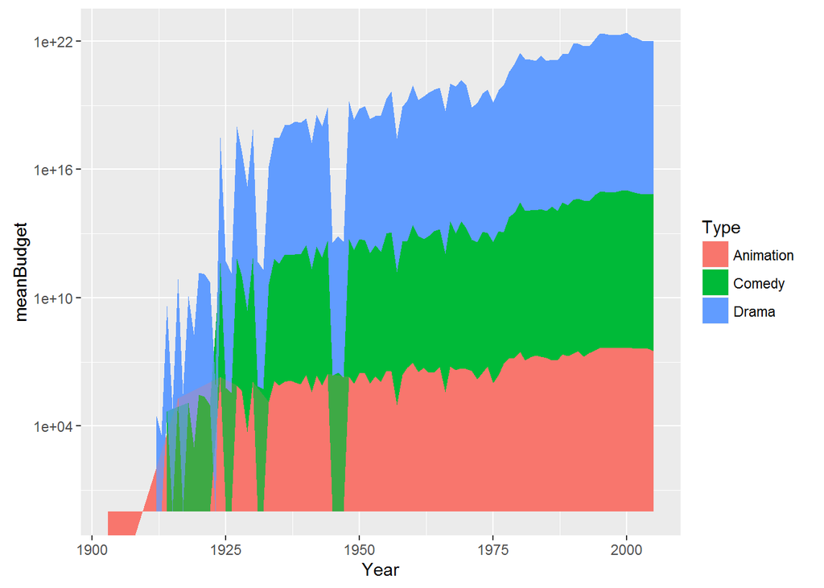

```r
ggarea1+geom_area(alpha=0.5) + scale_y_log10()
```

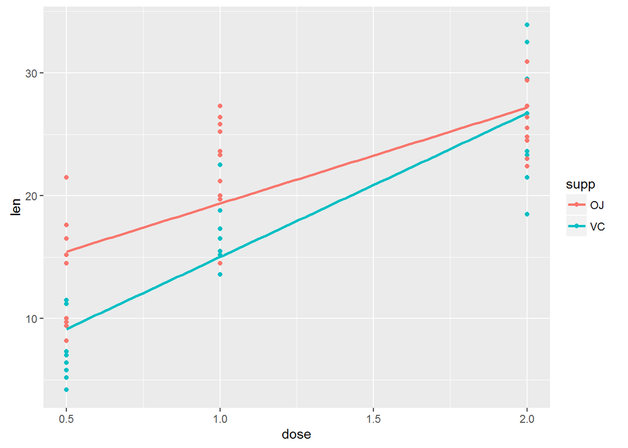

```r
ggplot(data=ToothGrowth, aes(x=dose, y=len, col=supp)) +
geom_point()+stat_smooth(method="lm",se=F)
```

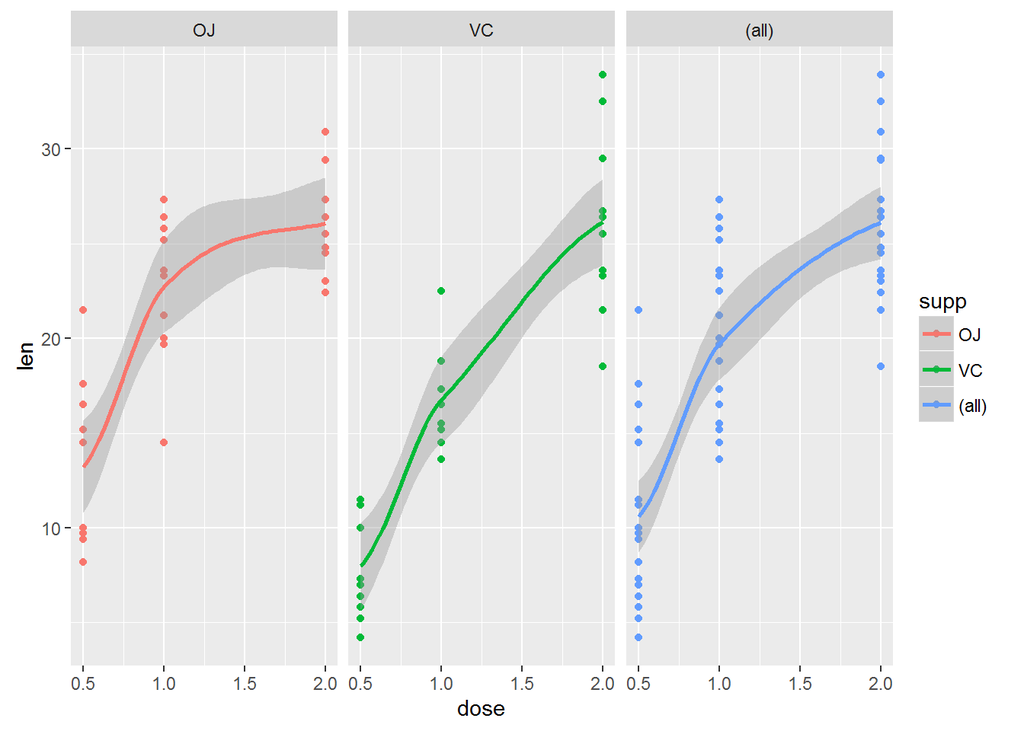

```r
ggplot(data=ToothGrowth, aes(x=dose, y=len, col=supp)) +
geom_point() + stat_smooth() + facet_grid(.~supp,margins=TRUE)
```

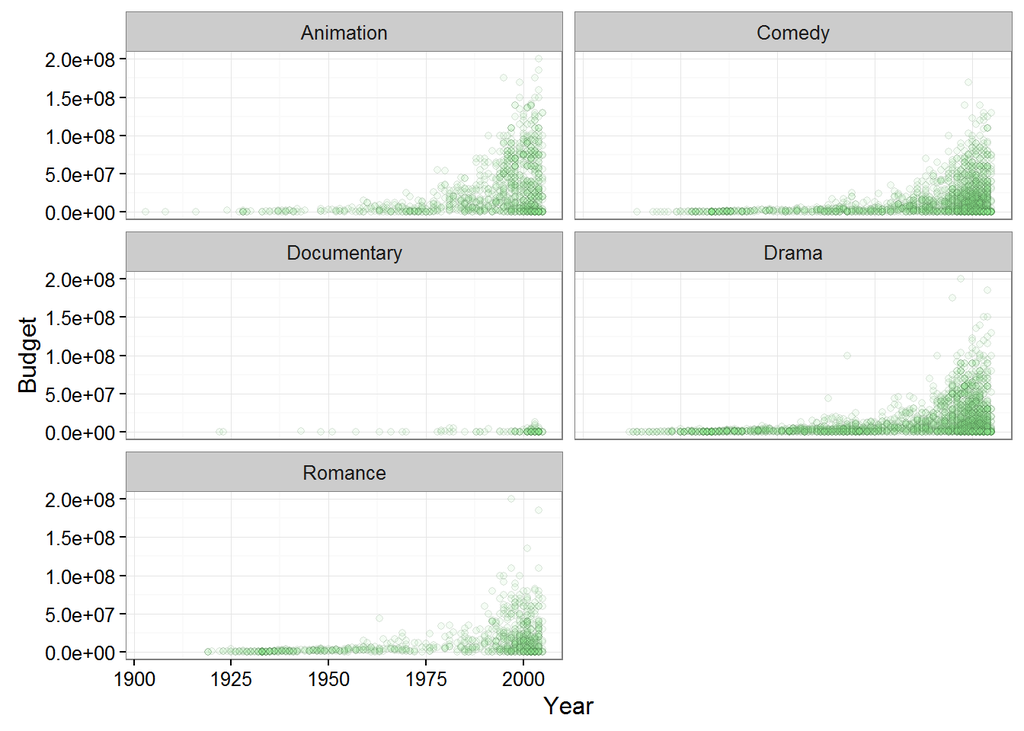

```r
gfacet2  <- ggplot(data=myMovieData, aes(x=Year, y=Budget)) +
geom_point(shape=21,alpha=0.1,fill="light green") + theme_bw()
gfacet2 + facet_wrap(~ Type,ncol=2,)
```

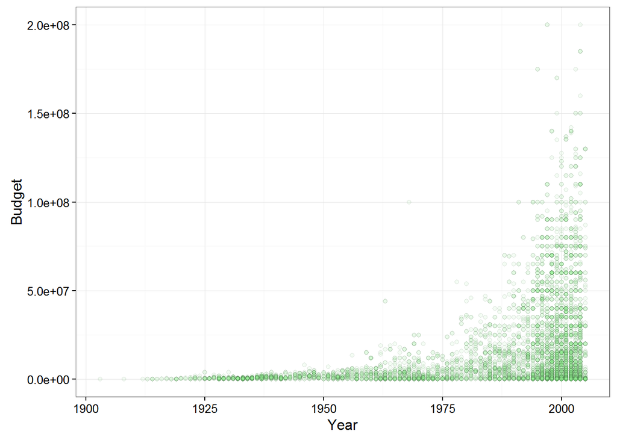

```r
gfacet2
```

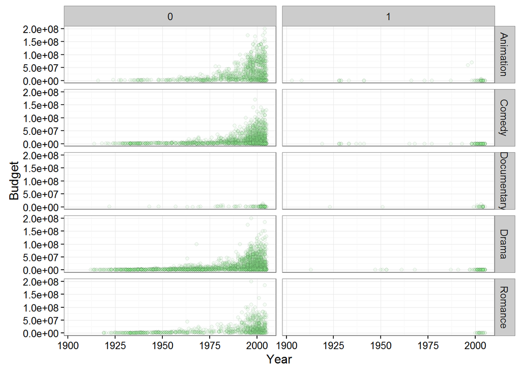

```r
gfacet2 + facet_grid(Type~Short)
```

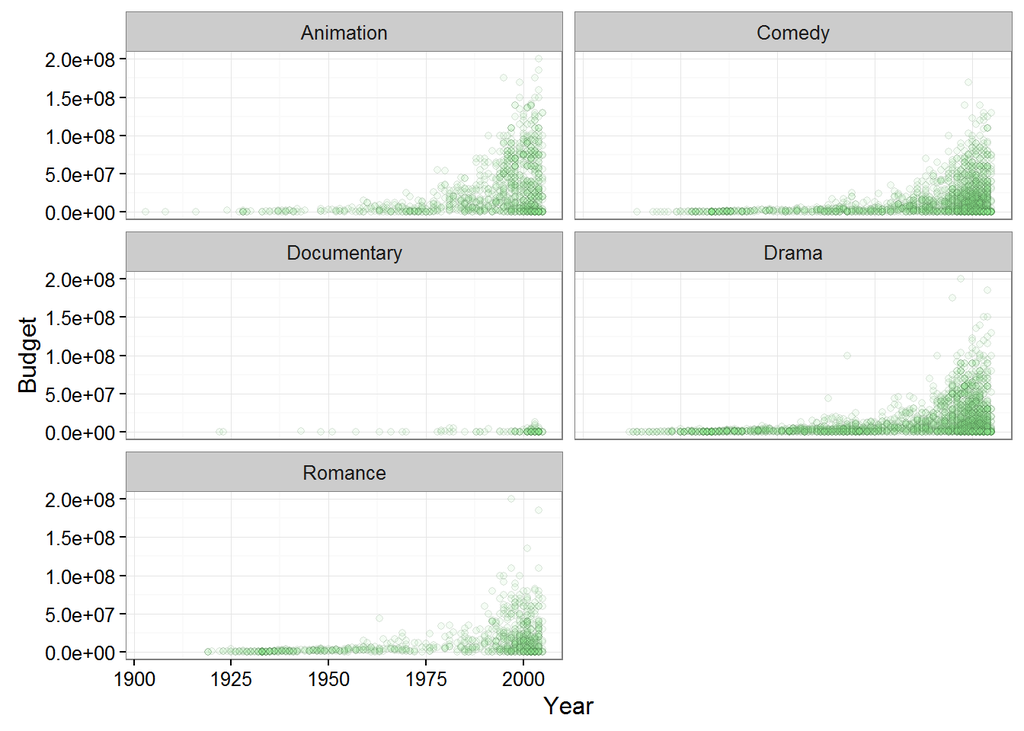

```r
gfacet2  <- ggplot(data=myMovieData, aes(x=Year, y=Budget)) +
geom_point(shape=21,alpha=0.1,fill="light green") + theme_bw()
gfacet2 + facet_wrap(~ Type,ncol=2,)
```

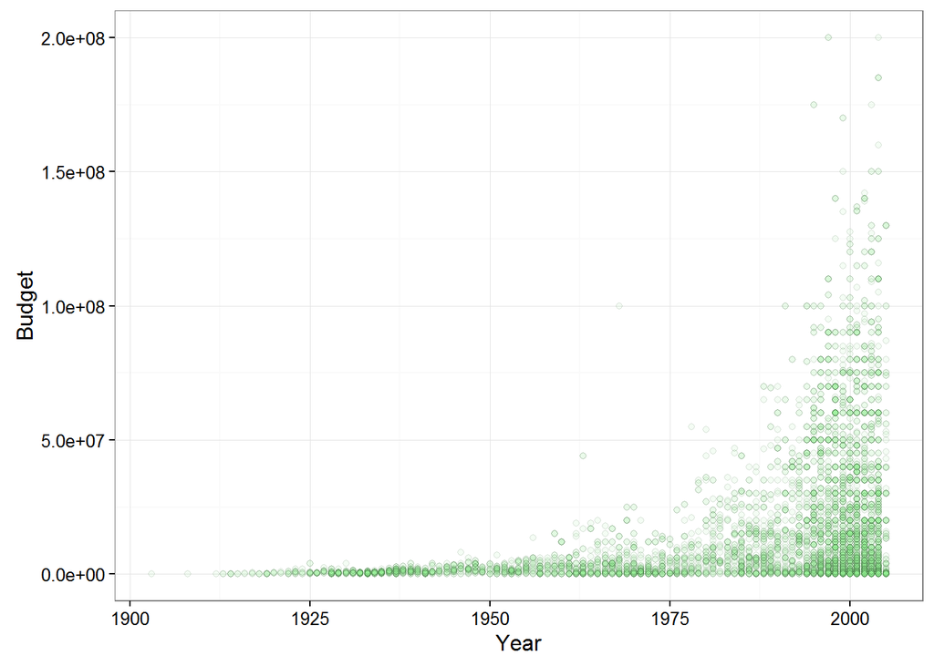

```r
gfacet2
```

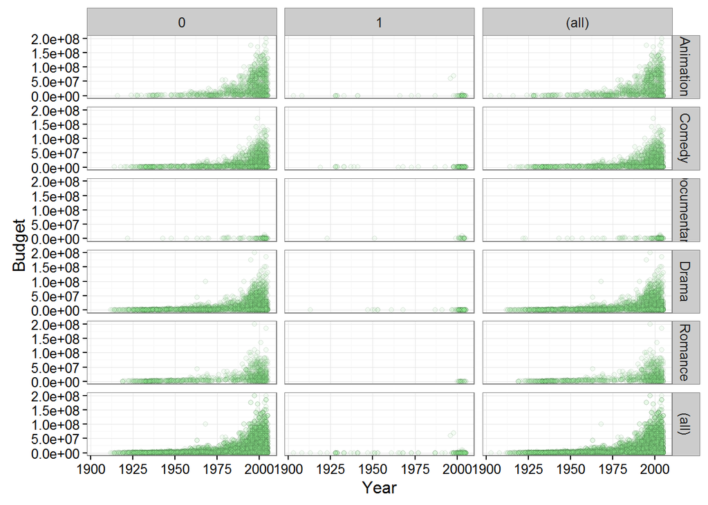

```r
gfacet2 + facet_grid(Type~Short,margins = T)
```